# Math 220 Spring 2023 Lecture Notes

Alice Miller

Updated: 10 April, 2023

## Math 220 Notes

Hi! This is RSTudio!

```r
2+2
```

```
## [1] 4
```

# Week 1

## Wed Jan 18

### Data Basics

Many formats for data!

Here (and in all DA classes), we only care about RECTANGULAR DATA (“tidy data”):

3 things:

- rows are CASES (individuals). Ie, from what person/animal/thing/whatev did we record? Eg: you guys! remember: rows are horizontal!
- columns are VARIABLES. Ie, the qualities of the individuals that we care about! columns are vertical!
- each “cell” must contain ONLY one observation/measurement

### Types of Data

Big breakdown: numerical (quantitative) or categorical (qualitative) ie: number or not!

All together, 4 types:

- discrete numerical data. “countable”. Actually counting real object/things/ideas.
- continuous numerical data. “measureable”. Eg: weight, volume, duration of time, etc.

  ```
   Philosopical note:  be careful about WHAT you're measuring.  Ex:
   Age = integer number of years.  discrete.
   Age = duration of time living on earth.  continuous.
   height = measuring tape.  continuous.  Possible to be 66.1", 66.7", 69.23423423"

   Weird example:  money.  gas?  pennies?  currency conversions? interest!
         Class agreement:  money is continous.
  ```

- nominal categorical. categorical, no INTRINSIC order.
- ordinal categorical. categrocial, YES natural order

MORAL OF THE STORY: Not all data is the same. We use DIFFERENT TOOLS for different types!

### Saying smart things about data (descriptive/summary stats)

Summary statistics for Categorical data: proportion!

Ex: In our class, 9/15 students had black hair.

phat:

```r
9/15
```

```
## [1] 0.6
```

Summary statistics for Quantitative data:

For quant variables, always describe:

1. center.
2. spread.
3. shape.

## Friday Jan 20

### Quantitative Variables (saying something smart)

Note: it doesn’t make sense to talk about ONE number in a dataset. Instead, we care about ALL of them, at the same time! “Distribution”.

ALWAYS MAKE A PICTURE FIRST!

For numerical data: HISTOGRAM!

Ex: class data:

```r
head(ourData)
```

```
##            X Year.in.School   Major Number.of.Siblings       Name.of.Hometown
## 1 Student 01      Sophomore      DA                  2                Chicago
## 2 Student 02      Sophomore Physics                  1           Hilliard, OH
## 3 Student 03      Sophomore      DA                  3       Hillsborough, CA
## 4 Student 04         Junior     Bio                  1       Vungtau, Vietnam
## 5 Student 05      Sophomore    Econ                  1          Lakeville, MN
## 6 Student 06      Sophomore      CS                  1 Buon Ma thuot, Vietnam
##   Population.of.Hometown Hair.Color Age Height..inches.
## 1              2,700,000      Brown  20              74
## 2                 37,114      Black  20              70
## 3                 11,000      Brown  20              70
## 4                454,000      Black  20              65
## 5                 72,000      Brown  19              70
## 6                502,175      Black  21              69
##     Favorite.Childhood.Activity
## 1                        Sports
## 2                   video games
## 3                       Sailing
## 4                   video games
## 5                Playing sports
## 6 playing soccer, chess, boxing
```

Q: what can we say about your height?

Hist!

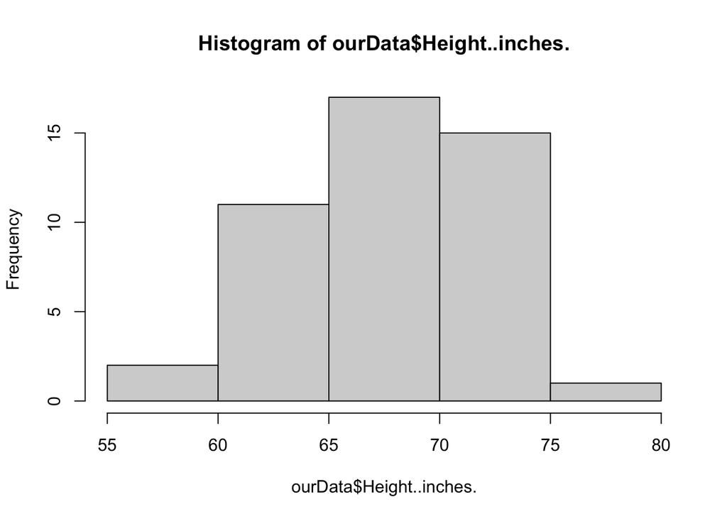

```r
hist(ourData$Height..inches.)
```

Observations:  
- typical height is around 67/68 - spread: looks like “most” values are btwn 62 - 72 - looks symmetrical “ish”

Q: what if we use more than 5 rectangles?

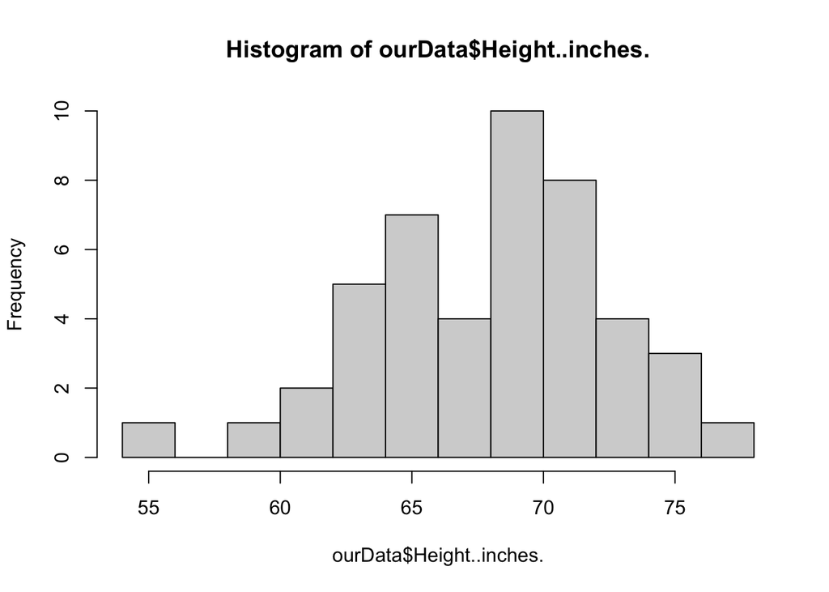

```r
hist(ourData$Height..inches., breaks = 10)
```

Interesting new feature! Bimodal! Q: could it be because of sex?

MORAL OF THE STORY: Follow the “Tao of the Histogram”!

Ex: our siblings

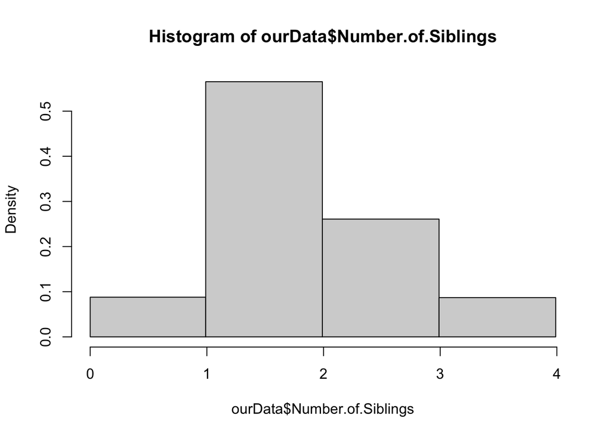

```r
hist(ourData$Number.of.Siblings, breaks = c(0,.99,1.99,2.99, 3.99))
```

Tao of the histogram!

### Summary Statistics

Ie, numerical summary of distribution.

- Measures of Center
  - Mean: average! “balancing point”
  - Median: “middle number”
  - Mode: most common number
- Measures of Spread
  - Range = max - min. Con: highly susceptiple to outliers.
  - Standard deviation = “average distance btwn points and the mean” Formula: on the board Note: must square to measure the TOTAL variation!
  - IQR. Quartiles: cutoffs for 25% (Q1) and 75% (Q3) in the dataset. IQR = Q3 - Q1

    Ex: Data = {15, 16, 16, 18, 20, 27}

    Compute IQR = 20 - 16 = 4

    (M = 17, Q1 = 16, Q3 = 20)

    Meaning: range of the MIDDLE 50% of the data!

A statistic is ROBUST if it is NOT strongly affected by skew or outliers.

Ex: Data = {1,1,1,1,1,19}

Mean = 4, Med = 1. Seems like median is better!

# Week 2

## Wed Jan 25

Distribution: The salaries of all employees at a major corporation.

Which would provide a rosier picture of compensation: the mean or the median?

A: expect strong right skew (tail)! expect mean to be bigger (since not robust).

### Outliers

Q: what “counts” as an outlier? Need a test!

Q: There are two sections of calculus. Both take the same exam, both class means are the same.

Is it possible that a student who scores 95 in one section could be an outlier, but a student with same score in the other is NOT an outlier?

Yes! Must factor in the spread!

Let’s use IQR! (robust!)

“Cutoffs” for outliers:

low = Q1 - 1.5(Q3-Q1) IQR hi =. Q3 + 1.5(Q3-Q1) IQR

Ex: Data = { 1, 2, 3, 4, 5, 6, 7, 8, 8, 20}

Q: are there outliers?

M = 5.5 Q1 = 3, Q3 = 8, IQR = 8-3 = 5

Cutoffs:

low:

```r
3 - 1.5*5
```

```
## [1] -4.5
```

hi:

```r
8 + 1.5*5
```

```
## [1] 15.5
```

### Boxplots

Great for comparison!

Ex: iris dataset

```r
head(iris)
```

```
##   Sepal.Length Sepal.Width Petal.Length Petal.Width Species
## 1          5.1         3.5          1.4         0.2  setosa
## 2          4.9         3.0          1.4         0.2  setosa
## 3          4.7         3.2          1.3         0.2  setosa
## 4          4.6         3.1          1.5         0.2  setosa
## 5          5.0         3.6          1.4         0.2  setosa
## 6          5.4         3.9          1.7         0.4  setosa
```

Ex: sepal length

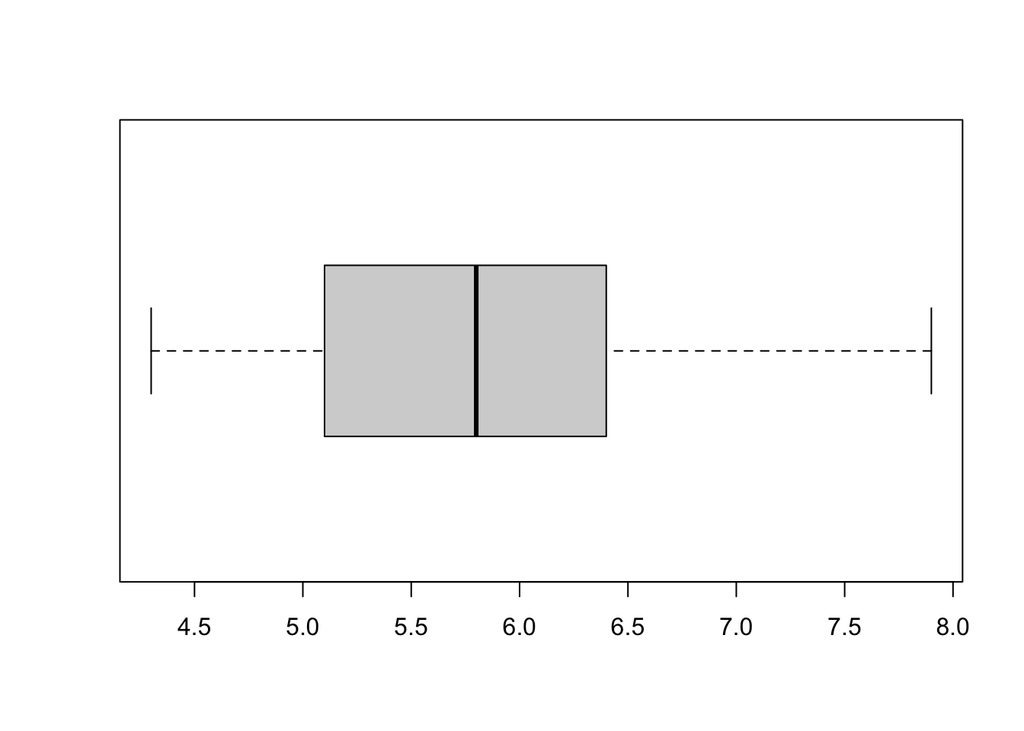

```r
boxplot(iris$Sepal.Length, horizontal = T)
```

Q: compare species?

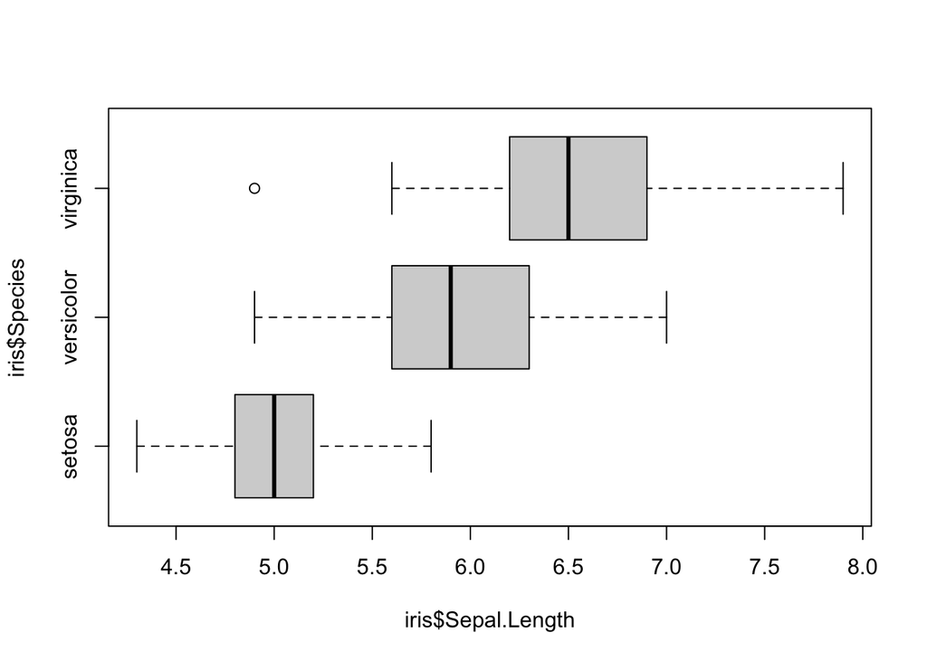

```r
boxplot(iris$Sepal.Length ~ iris$Species, horizontal = T)
```

### Ch 2 - Probability!

Plan: stay to close to book!

Key building blocks:

A random process / chance experiment is any scenario where more than one unknown outcome could occur!

Ex: Tossing a coin, rolling dice, sampling random student

Sample space = S = the set of all possible outcomes Event. = A = any subset of the sample space (what we care about!)

Ex: Rolling a dice. Let A be the event that we get an even number. Let B be the event that we get a prime.

S = {1,2,3,4,5,6} A = {2,4,6} B = {2,3,5}

goal: combine events into useful statements

3 tools:

- Complement. “not”. A’ is everything in S, NOT in A
- Union. A U B = all elements in either a OR b (could be both)
- Intersection A intersect B = all elements in both A AND B

Find:

A’ = {1,3,5} A U B = {2,3,4,5,6} A intersect B = {2}

## Friday Jan 27

2.2 Axioms of probability

The very basics!

For some event A, the probability of event A, denoted P(A), satisifies…

1). P(A) >= 0 (for any event A in our sample space S) 2). P(S) = 1. (since S is all possibilities) 3). If A, B are mutually exclusive, then:

```
        P(A U B) = P(A) + P(B)
```

Ex) Using only the axioms, prove that P(A’) = 1 - P(A)

Ex) Axioms, prove P(A) <= 1 for any A

Ex). P(A U B) = P(A) + P(B) - P(A and B)

Exercise: prove from axioms! (it’s in the book!)

Ex). Cards! If we draw at random, what’s the prob that our card is a heart or a face?

P(H U F) = P(H) + P(F) - P(H and F)

```
        = 13/52 + 12/52 - 3/52
```

### 2.3 - Counting Techniques

The PRODUCT RULE: if we make a sequence of k decisions, - with n1 options for the first, - n2 options for the second, …. - nk options for the kth decision.

If the decision at any one stage doesn’t affect any other, then there are:

```
     n = n1 * n2 * n3 * ... * nk total possibilities
```

Ex). We toss a coin 3 times. How many possible outcomes? Ex: H H H

Ex). Roll 2 dice. How many outcomes?

```
      6 * 6 = 36
```

Ex). In OH, license plates have 3 letters followed by 4 numbers.

How many plates are possible?

```r
26^3*10^4
```

```
## [1] 175760000
```

Ex). Above, but no letter “O”, can’t end on an odd number.

### Permutations

Ex) How many arrangements of the letters in ALICE are there?

Ex) How many arrangments of the letters in BANANA are there?

Ex) There are 20 children. 3 swings. How many seating arrangements are there?

### Combinations

Ex). There are 20 children. We need to pick a team of 3 children. How many teams?

Problem: teams have no arrangement/order!

What’s the difference? ORDER!!!

Perms - order matters!

Combs - doesn’t

# Week 3

## Monday Jan 30

Ex). In a tennis league, there are 16 players. How many possible matchings are there?

Ex2). Same league. After a competition, someone gets 1st place, 2nd place, 3rd place. How many possible awards brackets?

Ex3). We toss 8 coins. What’s the probability of getting:

```
       H H H H T T T T

       H T H T H T H T
```

Ex4). We toss 8 coins. WHat’s the probability of getting exactly 4 heads?

P(Exactly 4 heads) = 70/2^8

```r
70/2^8
```

```
## [1] 0.2734375
```

Ex5) We toss 10 coins. What’s the probabilit of exactly 3 Heads?

Future: binomial dist!

Alternate version:

Ex3). Roll a dice 10 times. What’s the probability that the first 3 rolls show “4”?, no others are 4.

Ex: 4 4 4 1 2 3 2 1 5 6

Ex4). What’s the prob that the LAST 3 rolls show “4”?

Same thing!

Ex5). What’s the prob that EXACTLY 3 of the 10 rolls shows “4”?

Future: binomial distribution

### Card Example

Ex6). Cards.

Draw a 5-card hand (from 52 card deck).

a). How many possible hands.

```r
choose(52,5)
```

```
## [1] 2598960
```

2. What’s the probability of getting one pair?

   Ex: 3 3 J A 7

   NO: 3 3 3 A 7

   No: 3 3 3 3 K

   NO: 3 3 J J K

Decisions:

```
- decide which kind for the pair?  13 C 1

- decide which for the pair?   4 C 2

- decide kinds for other 3 cards:  12 C 3

- for each of the three: which suit?  4C1 * 4C1 * 4C1
```

Final: 13C1 * 4C2 * 12C3 * 4C1 * 4C1 * 4C1

Practice: wikipedia! Google: “wiki poker probabilities”

### 2.4 Conditional Probability

Idea: if it’s cloudy, more likely to rain.

```
  P(A | B) = "the probability that A happens, GIVEN that B has occurred"

           = P(A and B) / P(B)
```

Ex) At DU, 52% of students are female, 48% male. About 8.2% of all students are female STEM majors.

If we select a student at random, and that student is female, what’s the probability that she’s a STEM major?

given: female!

Need: P(S | F) = P(S and F)/P(F) = .082/.52

Ex) Lie detector test. It advertises itself as 95% accurate. This means that IF a person is lying, then there’s a 95% chance of a + result.

However, we also know that if a person is NOT lying, there’s a 90% chance the test shows -.

Suppose that most people (99%) are honest.

1. Draw a probability tree to summarize.

b). What’s the prob a rando person tests “+”?

Only options: L and +, or. L’ and +

```r
.01*.95 + .99*.1
```

```
## [1] 0.1085
```

This is “Total Prob!”. Breaking it down into cases.

3. If the test says you’re lying, what’s the prob that you’re actually lying?

P(L | + ) = P( L and + )/P(+)

Tree:

```r
.01*.95/(.01*.95 + .99*.1)
```

```
## [1] 0.0875576
```

If you get +, there’s only an 8.7% chance that you really lied!

Q: Why so small?

### 2.5 Independence

Idea: somtimes, one outcome DOES NOT AFFECT another!

Independence!

Ex: coin tosses.

Math definition:

We say events A,B are INDEPENDENT if:

```
     P(A | B ) = P(A)

     P(B | A ) = P(B)
```

if one is true, so is the other.

Ex: poker and snacks

P(P|C)

```r
12/30
```

```
## [1] 0.4
```

P(P)

```r
25/115
```

```
## [1] 0.2173913
```

Q: are these different enough to suggest not independent?

Ex). Text (Example 2.36)

## Friday Feb 3

Independence:

```
 P(A | B) = P(A)
 P(B | A) = P(B)
```

EASY WAY TO CHECK:

```
     P(A and B) = P(A)*P(B)
```

Ex) Cards! Are the events “draw a heart” and “draw a face card” independent?

Justify mathematically.

```
  Check:    P(H and F) =? P(H)*P(F)

                3/52   =?  13/52 * 12/52
```

```r
3/52
```

```
## [1] 0.05769231
```

```r
13/52 * 12/52
```

```
## [1] 0.05769231
```

Independent events!

### Ch 3.1 - 3.2 Probability Distributions

Idea: think more holistically about probability.

RANDOM VARIABLE: map each outcome in sample space to real number.

Ex1. Roll dice. Let X = the number that shows. Possible values for X = {1,2,3,4,5,6}

Ex2. Roll two dice. Let X = their sum. values for X = {2,3,4,…,11,12}

Ex3. Toss a coin repeatedly until get H. Then stop. Let X = the number of coin tosses. {1, 2, 3, …. }

A *discrete* PROBABILITY DISTRIBUTION for a RV X is:

- a list of all possible values for X
- for each, an associated probability.

Notes:

- the SUPPORT for the distribution is the set of all X with nonzero prob {1,2,3,4,5,6}
- 0 <= P(x) <= 1 for all x in support
- sum( P(x) ) = 1

Ex1-3) Construct distributions for the RVs listed above. [Solved on the board].

### Cumulative distributions

CDF - cumulative distribution function

on board

Notes about CDF:

- every cdf is defined on ENTIRE REAL LINE
- left hand limit = ____
- right hand limit = ____

Why cdf?

A: very useful for RANGES of options for X

Ie:

```
     P(a <= X <= b) = F(b) - F(a-)     <- book, p106
```

Ex: What’s the prob we roll a number btwn 2 and 5 (inclusive)?

```
    P(2 <= X <= 5) = F(5) - F(1) = 5/6 - 1/6 = 4/6
```

# Week 4

## Monday Feb 6

### 3.3 Expected Value and Variance for Discrete RV

Before: described data that happenED

Now: expectations for the future! prob!

### Expected Value

E[X] = sum( x*P(X=x) )

Ex). Dice Distro.

```r
1*1/6 + 2*1/6 + 3*1/6 + 4*1/6 + 5*1/6 + 6*1/6
```

```
## [1] 3.5
```

If we rolled the dice MANY times, we’d expect an average close to 3.5.

### Variance

V[X] =

Ex) Find V for dice distro.

V[X]

```r
(1-3.5)^2*1/6 + (2-3.5)^2*1/6 + (3-3.5)^2*1/6 + (4-3.5)^2*1/6 + (5-3.5)^2*1/6 + (6-3.5)^2*1/6
```

```
## [1] 2.916667
```

SD[X]

```r
sqrt(2.91666666)
```

```
## [1] 1.707825
```

### Linear Transformations of RVs

```
 E[ h(X) ] = sum( h(x)*P(X=x) )

 E[ X^2 ] = sum( x^2 * P(X=x) )
```

Linear trans: (p115)

```
 Y = aX1 + bX2 + c

 where X1, X2 are RVs, and a,b,c are constants

 then:

 E[Y] = a * E[X1] + b * E[X2] + c

 V[Y] = a^2 * V[X1] + b^2 * V[X2]

 SD[Y] = sqrt(V[Y]).  (WARNING:  must find V first!)
```

Ex). A grad program values the math portion of entrance exam twice as much as the verbal.

Transf:

```
 Y = 2*X1 + 1*X2

     where X1 = math score, X2 = verbal
```

Info:

```
math:   mean = 120,  stdev = 5
verb:   mean = 160,  stdev = 7
```

Q: What are the mean and stdev of weighted score?

E[Y] = 2*E[X1] + 1*E[X2] = 2*120 + 1*160

```r
2*120 + 1*160
```

```
## [1] 400
```

V[Y] = 2^2*V[X1] + 1^2*V[X2] = 2^2 * 5^2 + 1^2 * 7^2

```r
2^2 * 5^2 + 1^2 * 7^2
```

```
## [1] 149
```

stdev:

```r
sqrt(149)
```

```
## [1] 12.20656
```

Note: must get V first!

### 3.4-3.6 (Skip 3.5) Meet the Famous Prob Distros!

1. Bernoulli.

   X ~ bernoulli(p) [NOTE: p is a “parameter” ]

Only two outcomes: X=0 (fail) or X=1 (success).

```
P(X = 1) = p       (prob of success)
P(X = 0) = 1-p

E[X] = p
V[X] = p(1-p)       <- check later!
```

2. Binomial Dist

   X ~ binom(n,p)

ASSUMPTIONS:

- there are a fixed number (n) of trials
- only two outcomes for each trial: success or fail (bernoulli!)
- all trials are independent
- CONSTANT probability of success (p) in each trial

Ex). If we roll dice 10 times, what’s the prob that exactly 3 of them show “4”?

X~binom(10,1/6)

## Wed Feb 8

### Famous Distros

1. Bernoulli

   Support: {0,1}

2). Binomial

X~binom(n,p)

X counts the number of successes out of n trials.

Ex). At DU, about 80% of students are from out-of-state.

If we take a sample of 6 students, what’s the prob that exactly 3 of them are from out-of-state?

X ~ binom(6, .8)

P(X=3)

```r
20*.8^3*.2^3
```

```
## [1] 0.08192
```

Binomial facts:

Support: {0,1,2,..,n}

```
E[X] = n*p

V[X] = n*p*(1-p)
```

3. Geometric Distribution

X ~ geom(p)

X = the number of trials needed until the first success.

Ex: We toss a coin repeatedly until get H. WHat’s the prob it takes 5 times?

P(T and T and T and T and H) = (1/2)^4 * 1/2

Ex). Suppose we choose students at random until we get one from Ohio. (remember: 80% from out-of-state).

What’s the prob that we must sample at least 3 students until we get the first from Ohio?

Support: {1,2,3,….}

Expected Value: E[X] = 1/p. ONLY FOR GEOMETRIC! Variance: V[X] = (1-p)/p^2

4. Poisson Dist

X ~ pois(mu)

X = the number of occurrences of a random event over an interval of space/time

Assumptions:

- events happen randomly and independently
- constant chance of occurrance at any given time/place
- the liklihood of occurance is proportionate to the length of the interval (more time -> more likely!)

Ex). Since 1883, Tokyo has experienced 5 earthquakes of the “most severe” category.

Assuming constant likelihood over time, what’s the probability that at least one occurs in the next year? In the next 10 years?

mu = 5quakes/140years = 5/140

P(X>=1) = P(X=1) + P(X=2) + ….. = 1 - P(X=0)

```r
1-exp(-5/140)*(5/140)^0/1
```

```
## [1] 0.03508406
```

b). next 10 years?

idea: unit changed! want quakes/10year period

mu = 10*5/140 = 50/140

```r
1-exp(-50/140)*(50/140)^0/1
```

```
## [1] 0.3003275
```

### Ch 4 - Continuous Distributions

Ex. Height is cts.

In US, avg height for women is 64”, stdev = 2.4”.

What’s the prob that a rando woman is EXACTLY 64.0000000000….”

A: zero! weird!

True for ALL cts dist:

```
 P(X = a) = 0        for any a!
```

So, only makes sense to talk about RANGES for cts variables.

What to do? probability DENSITY function!

## Friday Feb 10

### Ch4: Continuous Dists

Idea: need a DENSITY function. f(x). pdf. probability = AREA under the curve!

### Uniform Dist

“straight line dist”

Ex) Suppose the time you wait at a bus stop varies uniformly btwn 5 and 15 min.

X~unif(5,15)

a). sketch the pdf

2. What’s P(X<7)

c). What’s P(X<=7)

d). What’s P(X=7) = 0

In general:

```
X cts:     P(a <= X <= b) = P(a < X < b)

WARNING:  not true for X discrete!
```

Ex). Suppose f(x) = kx^2 0 <= x <= 2. (0 otherwise.) What value of k makes f(x) a valid pdf?

Ex). Compute P(X<1) = F(1)

### 4.2: Cdf, E[X], V[X]

```
cdf = all probability to the lEFT

F(x) = P(X <= x)
```

Ex). Find cdf for above dist.

f(x) = (3/8) x^2 0 <= x <= 2. (0 otherwise.)

Ex). Find P( 1/2 < X < 1 ). = F(1) - F(1/2)

```
                        = 1^3/8 - (1/2)^3/8
```

Ex). Find cdf for X~unif(a,b)

### E[X] and V[X]

Before: X discrete:

E[X] = sum( x*P(x) )

Now: replace sum with integral!

V[X] = sum( (x-mu)^2 * P(x) )

Now: replace with integrals!

Ex. Compute E[X] for above

f(x) = 3/8 x^2 0 <= x <= 2. (0 otherwise.)

4.13e) (p155) What’s the prob that headway (X) is within 1 standard deviation of the mean value?

Ex). Draw a 5-card hand at random. What’s prob of 1 pair?

Ex: 3 3 7 J Q

NO: 3 3 3 J Q

NO: 3 3 7 7 Q

Decisions:

- which kind for pair? 13C1
- which 3s? 4C2
- what kind for remaining? 12 C 3
- for each card: 4C1. (three of them)

Prob:

```
( 13C1 * 4C2 * 12C3 * (4C1)^3 ) / 52C5

(number of ways for 1 pair) / total number of 5-card hands
```

Since 1883, tokyo had 5 serious quakes. What’s the prob of at least 8 quakes in the next year?

X ~ pois(mu=5/140)

P(X >= 8) = P(8) + P(9) + P(10) + …

```
      = 1 - P(7) - P(6) - ... - P(1) - P(0)
```

Ex) Draw a 5-card hand. What’s the prob of getting 1 pair?

Ex: 3 3 7 J K

No: 3 3 3 7 J

No: 3 3 7 7 J

Decisions:

- which kind for the pair? 13C1
- which couple to use? 4C2
- what kind for other 3? 12C3
- for each, which suit? 4C1 for each!

P(pair) = ( 13C1 * 4C2 * 12C3 * (4C1)^3 ) / 52C5

14. blah blah blah has uniform distribution on (7.5,20) as a model of depth.

a). what are mean and variance of depth?

```r
20^2/25 - 7.5^2/25
```

```
## [1] 13.75
```

```r
20^3/(12.5*3) - 7.5^3/(12.5*3)
```

```
## [1] 202.0833
```

```r
202.08 - 13.75^2
```

```
## [1] 13.0175
```

# Week 5 (Exam I Week)

## Fri Feb 17

### 4.3 Normal Distribution

Ad: shows up in nature allll the time!

Idea: Most of us are in the middle! More extreme is less likely.

Note: Tail area is non-negative allll the way down to +/- infty.

Fortunately, gets small quickly.

### pdf/cdf for normal dist

problem: f(x) is NOT INTEGRABLE BY HAND!

Need computational aid:

- table of values
- software (r)

Problem! WHat are mu and sigma?

In general: from the problem.

Table: STANDARD NORMAL DIST!!!

```
   mu = 0,  sigma = 1
```

Ex). Suppose Z~normal(0,1)

(ie, std normal!)

a). P(Z < 2.76) = .9971

2. P(Z > 2.76) = 1 - .9971

```r
1-.9971
```

```
## [1] 0.0029
```

3. P(Z<=2.76) = same as a

d). P( -0.25 < Z < 1.87 )

F(1.87) = .9693 F(-0.25) = .4013

```r
.9693 - .4013
```

```
## [1] 0.568
```

### Backwards problems

Suppose Z has std normal dist.

a). How large would Z have to be in order to be at the 90th percentile?

z = 1.28

Note: won’t always be exact. Pick the closest.

b). How large would z have to be in order to be in the 40th percentile?

z = -.25

### z-scores

Problem: real world data NOT standard normal!

Solution: z-score!

z-scores CONVERT to std normal dist!

Ex). Height for adult women in US follows normal dist with mean 64”, stdev 2.4”.

a). What’s prob that rando woman is less than 65” tall?

P(X<65) = ?

z = (65 - 64)/2.4

```r
(65 - 64)/2.4
```

```
## [1] 0.4166667
```

look up in table! ->. left area = .6628.

About a 66.3% chance.

b). What’s the prob that rando woman is at least 75” tall? z

```r
(75 - 64)/2.4
```

```
## [1] 4.583333
```

uh-oh! off the charts!

area < .002

area ~ 0

3. How tall must a woman be in order to be in the top 5% of womens’ heights?

First: find z-score from table!

halfway btwn: 1.64 and 1.65. average them! z = 1.645

now: solve for x!

```r
1.645*2.4 + 64
```

```
## [1] 67.948
```

She’d have to be at least 67.948” tall.

# Week 6

## Monday Feb 20

### 4.3 Normal dist

normal dist in r.

Ex. If Z has std normal dist, Z~norm(0,1)

1. (Forwards). P(Z<1.49) = .9319

in r: “pnorm(zscore)”

```r
pnorm(1.49)
```

```
## [1] 0.9318879
```

2. (Backwards) How large must Z be to be at the 60th percentile?

z = .25

in r: qnorm(percentile)

```r
qnorm(.6)
```

```
## [1] 0.2533471
```

3. Heights for men in US follow normal dist with mean 69”, stdev 2.7”.

What’s the prob that rando man is btwn 66” and 70” tall?

find z-score!

x=70:

```r
(70-69)/2.7
```

```
## [1] 0.3703704
```

x=66

```r
(66-69)/2.7
```

```
## [1] -1.111111
```

P(-1.11 < Z < 0.37) =

```r
pnorm(.37)
```

```
## [1] 0.6443088
```

```r
pnorm(-1.11)
```

```
## [1] 0.1334995
```

area:

```r
pnorm(.37)-pnorm(-1.11)
```

```
## [1] 0.5108092
```

About 51.1% of men are btwn 66” and 70”.

4. In what range of heights (low - to - high) are the middle 50% of mens’ heights?

z-score:

lo

```r
qnorm(.25)
```

```
## [1] -0.6744898
```

hi

```r
qnorm(.75)
```

```
## [1] 0.6744898
```

Got z, now solve for x!

lo:

```r
-.67*2.7+69
```

```
## [1] 67.191
```

hi:

```r
.67*2.7+69
```

```
## [1] 70.809
```

The middle 50% of mens’ heights are btwn 67.2” and 70.8”.

IQR:

```r
70.8-67.2
```

```
## [1] 3.6
```

### 4.3 Normal (cont) Normal approximation to the Binomial Dist

Idea: for large n, then binomial looks just like normal!

Can be VERY CONVENIENT to replace complicated binomial with simple normal!

Ex) We roll a dice 100 times. What’s the prob that no more than 20 rolls show “4”?

Note: here, n is “large”!

- n*p > 10. <- at least 10 successes
- n*(1-p) > 10 <- at least 10 failures

mu

```r
100*1/6
```

```
## [1] 16.66667
```

sigma

```r
sqrt(100*1/6*5/6)
```

```
## [1] 3.72678
```

Find z-scores!

P(X<=20)

```r
(20-16.667)/3.727
```

```
## [1] 0.8942849
```

area from table:

```r
pnorm(.89)
```

```
## [1] 0.8132671
```

There’s about 81.3% chance of no more than 20 “4”s in 100 rolls.

b). What’s prob that we get EXACTLY 17 “4”s in 100 rolls?

X~norm(16.667, 3.727)

P(X=17) = 0

Fix: “continuity correction”

Fudge: P(16.5 < X < 17.5)

z-scores!

17.5:

```r
(17.5-16.667)/3.727
```

```
## [1] 0.2235042
```

16.5:

```r
(16.5-16.667)/3.727
```

```
## [1] -0.04480816
```

area:

```r
pnorm(0.22)-pnorm(-0.04)
```

```
## [1] 0.1030179
```

There’s about a 10.3% chance of getting 17 “4”s in 100 rolls.

d). Use continuity correction to compute P(X<=20)

z-scores:

```r
(20.5-16.667)/3.727
```

```
## [1] 1.028441
```

```r
(-.5 - 16.667)/3.727
```

```
## [1] -4.606118
```

area:

```r
pnorm(1.03) - pnorm(-4.61)
```

```
## [1] 0.848493
```

### Summary of example calculations

roll dice 100 times. count “4”s.

X~binom(100,1/6)

X~norm(16.667, 3.727)

P(X<=20)

exact:

```r
pbinom(20,100,1/6)
```

```
## [1] 0.8481122
```

normal approx, no cont correction:

```r
pnorm(20,16.667,3.727)
```

```
## [1] 0.8144153
```

with cont correction:

```r
pnorm(20.5,16.667,3.727)-pnorm(-.5,16.667,3.727)
```

```
## [1] 0.8481268
```